# PH525.5x Section 2: Bioconductor Basics: GRanges and Biostrings

Lauren Kemperman

- Core Bioconductor structures for representing genes and genetic sequences

## Motivation and Introduction

- Case study: given genomic DNA extracted from human cells, where on the genome does the nuclear protein ESRRA (estrogen related receptor alpha) bind?
- Role of estrogen receptors in breast cancer
- Data comes from analysis of ChIP-seq experiments: performed in ENCODE project - import info for files in “narrowPeak” format and analyze in Bioconductor GRanges object
- Identifying nearest transcriptional start site for each binding peak - assess whether regulatory activity of ESRRA occurs in transcriptional promoter regions

```r
library(ERBS)
data(HepG2)
class(HepG2)
```

```
## [1] "GRanges"
## attr(,"package")
## [1] "GenomicRanges"
```

## GenomicRanges

```r
# install ERBS
library(devtools)
install_github("genomicsclass/ERBS")
```

```
## Skipping install of 'ERBS' from a github remote, the SHA1 (9f16eb6a) has not changed since last install.
##   Use `force = TRUE` to force installation
```

```r
library(GenomicRanges)
# load GM12878 and HepG2 objects from ERBS package
library(ERBS)
data(GM12878)
data(HepG2)

# inspect HepG2 GRanges object
class(HepG2)
```

```
## [1] "GRanges"
## attr(,"package")
## [1] "GenomicRanges"
```

```r
HepG2
```

```
## GRanges object with 303 ranges and 7 metadata columns:
##         seqnames              ranges strand |      name     score       col
##            <Rle>           <IRanges>  <Rle> | <numeric> <integer> <logical>
##     [1]     chr2   20335378-20335787      * |        NA         0      <NA>
##     [2]    chr20       328285-329145      * |        NA         0      <NA>
##     [3]     chr6 168135432-168136587      * |        NA         0      <NA>
##     [4]    chr19     1244419-1245304      * |        NA         0      <NA>
##     [5]    chr11   64071828-64073069      * |        NA         0      <NA>
##     ...      ...                 ...    ... .       ...       ...       ...
##   [299]     chr4     1797182-1797852      * |        NA         0      <NA>
##   [300]     chr1 110198573-110199126      * |        NA         0      <NA>
##   [301]    chr17   17734052-17734469      * |        NA         0      <NA>
##   [302]     chr1   48306453-48306908      * |        NA         0      <NA>
##   [303]    chr12 123867207-123867554      * |        NA         0      <NA>
##         signalValue    pValue      qValue      peak
##           <numeric> <numeric>   <numeric> <integer>
##     [1]      58.251    75.899 6.14371e-72       195
##     [2]      10.808    69.685 5.02806e-66       321
##     [3]      17.103    54.311 7.93067e-51       930
##     [4]      12.427    43.855 1.35976e-40       604
##     [5]      10.850    40.977 7.33386e-38       492
##     ...         ...       ...         ...       ...
##   [299]       9.681    10.057 1.42334e-08       402
##   [300]       7.929    10.047 1.44208e-08       197
##   [301]       5.864     9.990 1.63892e-08       227
##   [302]       5.660     9.948 1.79941e-08       211
##   [303]      13.211     9.918 1.92180e-08       163
##   -------
##   seqinfo: 93 sequences (1 circular) from hg19 genome
```

```r
values(HepG2)
```

```
## DataFrame with 303 rows and 7 columns
##          name     score       col signalValue    pValue      qValue      peak
##     <numeric> <integer> <logical>   <numeric> <numeric>   <numeric> <integer>
## 1          NA         0        NA      58.251    75.899 6.14371e-72       195
## 2          NA         0        NA      10.808    69.685 5.02806e-66       321
## 3          NA         0        NA      17.103    54.311 7.93067e-51       930
## 4          NA         0        NA      12.427    43.855 1.35976e-40       604
## 5          NA         0        NA      10.850    40.977 7.33386e-38       492
## ...       ...       ...       ...         ...       ...         ...       ...
## 299        NA         0        NA       9.681    10.057 1.42334e-08       402
## 300        NA         0        NA       7.929    10.047 1.44208e-08       197
## 301        NA         0        NA       5.864     9.990 1.63892e-08       227
## 302        NA         0        NA       5.660     9.948 1.79941e-08       211
## 303        NA         0        NA      13.211     9.918 1.92180e-08       163
```

```r
# seqnames extracts chromosome names
seqnames(HepG2)     # stored as type Rle
```

```
## factor-Rle of length 303 with 292 runs
##   Lengths:     1     1     1     1     1 ...     1     1     1     1     1
##   Values : chr2  chr20 chr6  chr19 chr11 ... chr4  chr1  chr17 chr1  chr12
## Levels(93): chr1 chr2 chr3 ... chrUn_gl000247 chrUn_gl000248 chrUn_gl000249
```

```r
chr = seqnames(HepG2)
as.character(chr)    # view as character type
```

```
##   [1] "chr2"  "chr20" "chr6"  "chr19" "chr11" "chr20" "chr19" "chr2"  "chr16"
##  [10] "chr3"  "chr6"  "chr20" "chr7"  "chr16" "chr9"  "chr11" "chr22" "chrX"
##  [19] "chr8"  "chr16" "chr16" "chr19" "chr17" "chr17" "chr16" "chr1"  "chr16"
##  [28] "chr9"  "chr17" "chr16" "chr12" "chr6"  "chr2"  "chr3"  "chr11" "chr16"
##  [37] "chr6"  "chr2"  "chr8"  "chr1"  "chr17" "chr20" "chr4"  "chr14" "chr19"
##  [46] "chr20" "chr9"  "chr2"  "chr2"  "chr19" "chr8"  "chr14" "chr22" "chr2"
##  [55] "chr14" "chr6"  "chr20" "chr2"  "chr19" "chr8"  "chr2"  "chr19" "chr12"
##  [64] "chr2"  "chr2"  "chr11" "chr12" "chr7"  "chr19" "chr22" "chr17" "chr3"
##  [73] "chr8"  "chr3"  "chr15" "chr6"  "chr9"  "chr10" "chr6"  "chr2"  "chr19"
##  [82] "chr11" "chr8"  "chr17" "chr15" "chr21" "chr7"  "chr2"  "chr2"  "chr3"
##  [91] "chr2"  "chr16" "chr10" "chr20" "chr17" "chr13" "chr2"  "chr5"  "chr14"
## [100] "chr11" "chr8"  "chr20" "chr3"  "chr7"  "chr1"  "chr1"  "chr3"  "chr17"
## [109] "chrX"  "chr19" "chr20" "chr6"  "chr7"  "chr16" "chr7"  "chr17" "chr20"
## [118] "chr2"  "chr5"  "chrX"  "chr7"  "chr6"  "chr19" "chr17" "chr16" "chr5"
## [127] "chr12" "chr9"  "chr20" "chr2"  "chr12" "chr3"  "chr7"  "chr2"  "chr20"
```

[output cut: 19 more lines]

```r
# make a table of numbers of sequences on each chromosome
table(chr)
```

```
## chr
##                  chr1                  chr2                  chr3
##                    18                    38                    15
##                  chr4                  chr5                  chr6
##                     4                     8                    24
##                  chr7                  chr8                  chr9
##                    14                    11                    12
##                 chr10                 chr11                 chr12
##                     9                     9                    13
##                 chr13                 chr14                 chr15
##                     2                     8                     5
##                 chr16                 chr17                 chr18
##                    31                    21                     6
##                 chr19                 chr20                 chr21
##                    16                    27                     3
##                 chr22                  chrX                  chrY
##                     5                     4                     0
##                  chrM  chr1_gl000191_random  chr1_gl000192_random
##                     0                     0                     0
##        chr4_ctg9_hap1  chr4_gl000193_random  chr4_gl000194_random
##                     0                     0                     0
##         chr6_apd_hap1         chr6_cox_hap2         chr6_dbb_hap3
##                     0                     0                     0
##        chr6_mann_hap4         chr6_mcf_hap5         chr6_qbl_hap6
##                     0                     0                     0
##        chr6_ssto_hap7  chr7_gl000195_random  chr8_gl000196_random
##                     0                     0                     0
##  chr8_gl000197_random  chr9_gl000198_random  chr9_gl000199_random
##                     0                     0                     0
##  chr9_gl000200_random  chr9_gl000201_random chr11_gl000202_random
##                     0                     0                     0
##       chr17_ctg5_hap1 chr17_gl000203_random chr17_gl000204_random
##                     0                     0                     0
## chr17_gl000205_random chr17_gl000206_random chr18_gl000207_random
##                     0                     0                     0
## chr19_gl000208_random chr19_gl000209_random chr21_gl000210_random
##                     0                     0                     0
##        chrUn_gl000211        chrUn_gl000212        chrUn_gl000213
##                     0                     0                     0
##        chrUn_gl000214        chrUn_gl000215        chrUn_gl000216
```

[output cut: 8 more lines]

```
##                     0                     0                     0
##        chrUn_gl000229        chrUn_gl000230        chrUn_gl000231
##                     0                     0                     0
##        chrUn_gl000232        chrUn_gl000233        chrUn_gl000234
##                     0                     0                     0
##        chrUn_gl000235        chrUn_gl000236        chrUn_gl000237
##                     0                     0                     0
##        chrUn_gl000238        chrUn_gl000239        chrUn_gl000240
##                     0                     0                     0
##        chrUn_gl000241        chrUn_gl000242        chrUn_gl000243
##                     0                     0                     0
##        chrUn_gl000244        chrUn_gl000245        chrUn_gl000246
##                     0                     0                     0
##        chrUn_gl000247        chrUn_gl000248        chrUn_gl000249
##                     0                     0                     0
```

```r
table(chr)[1:24]    # restrict to autosomes, X and Y
```

```
## chr
##  chr1  chr2  chr3  chr4  chr5  chr6  chr7  chr8  chr9 chr10 chr11 chr12 chr13
##    18    38    15     4     8    24    14    11    12     9     9    13     2
## chr14 chr15 chr16 chr17 chr18 chr19 chr20 chr21 chr22  chrX  chrY
##     8     5    31    21     6    16    27     3     5     4     0
```

```r
# GRanges can be subsetted and ordered
HepG2[chr=="chr20",]
```

```
## GRanges object with 27 ranges and 7 metadata columns:
##        seqnames            ranges strand |      name     score       col
##           <Rle>         <IRanges>  <Rle> | <numeric> <integer> <logical>
##    [1]    chr20     328285-329145      * |        NA         0      <NA>
##    [2]    chr20 22410891-22411863      * |        NA         0      <NA>
##    [3]    chr20 56039583-56040249      * |        NA         0      <NA>
##    [4]    chr20 16455811-16456232      * |        NA         0      <NA>
##    [5]    chr20   3140243-3140774      * |        NA         0      <NA>
##    ...      ...               ...    ... .       ...       ...       ...
##   [23]    chr20   5591571-5592037      * |        NA         0      <NA>
##   [24]    chr20 25519664-25520238      * |        NA         0      <NA>
##   [25]    chr20 19900951-19901275      * |        NA         0      <NA>
##   [26]    chr20 35156796-35157140      * |        NA         0      <NA>
##   [27]    chr20 25036720-25037716      * |        NA         0      <NA>
##        signalValue    pValue      qValue      peak
##          <numeric> <numeric>   <numeric> <integer>
##    [1]      10.808    69.685 5.02806e-66       321
##    [2]       6.419    41.020 7.74961e-38       660
##    [3]       7.796    36.977 3.66693e-34       315
##    [4]       7.351    21.831 1.59668e-19       199
##    [5]       7.296    21.587 2.62536e-19       315
##    ...         ...       ...         ...       ...
##   [23]       8.766    11.433 7.67742e-10       249
##   [24]       3.300    11.419 7.89520e-10       206
##   [25]       4.809    11.155 1.37954e-09       140
##   [26]      10.154    10.313 8.30971e-09       163
##   [27]       4.381    10.087 1.33278e-08       170
##   -------
##   seqinfo: 93 sequences (1 circular) from hg19 genome
```

```r
x = HepG2[order(HepG2),]
seqnames(x)     # demonstrate usefulness of Rle type
```

```
## factor-Rle of length 303 with 23 runs
##   Lengths:    18    38    15     4     8 ...    16    27     3     5     4
##   Values : chr1  chr2  chr3  chr4  chr5  ... chr19 chr20 chr21 chr22 chrX
## Levels(93): chr1 chr2 chr3 ... chrUn_gl000247 chrUn_gl000248 chrUn_gl000249
```

```r
as.character(seqnames(x))
```

```
##   [1] "chr1"  "chr1"  "chr1"  "chr1"  "chr1"  "chr1"  "chr1"  "chr1"  "chr1"
##  [10] "chr1"  "chr1"  "chr1"  "chr1"  "chr1"  "chr1"  "chr1"  "chr1"  "chr1"
##  [19] "chr2"  "chr2"  "chr2"  "chr2"  "chr2"  "chr2"  "chr2"  "chr2"  "chr2"
##  [28] "chr2"  "chr2"  "chr2"  "chr2"  "chr2"  "chr2"  "chr2"  "chr2"  "chr2"
##  [37] "chr2"  "chr2"  "chr2"  "chr2"  "chr2"  "chr2"  "chr2"  "chr2"  "chr2"
##  [46] "chr2"  "chr2"  "chr2"  "chr2"  "chr2"  "chr2"  "chr2"  "chr2"  "chr2"
##  [55] "chr2"  "chr2"  "chr3"  "chr3"  "chr3"  "chr3"  "chr3"  "chr3"  "chr3"
##  [64] "chr3"  "chr3"  "chr3"  "chr3"  "chr3"  "chr3"  "chr3"  "chr3"  "chr4"
##  [73] "chr4"  "chr4"  "chr4"  "chr5"  "chr5"  "chr5"  "chr5"  "chr5"  "chr5"
##  [82] "chr5"  "chr5"  "chr6"  "chr6"  "chr6"  "chr6"  "chr6"  "chr6"  "chr6"
##  [91] "chr6"  "chr6"  "chr6"  "chr6"  "chr6"  "chr6"  "chr6"  "chr6"  "chr6"
## [100] "chr6"  "chr6"  "chr6"  "chr6"  "chr6"  "chr6"  "chr6"  "chr6"  "chr7"
## [109] "chr7"  "chr7"  "chr7"  "chr7"  "chr7"  "chr7"  "chr7"  "chr7"  "chr7"
## [118] "chr7"  "chr7"  "chr7"  "chr7"  "chr8"  "chr8"  "chr8"  "chr8"  "chr8"
## [127] "chr8"  "chr8"  "chr8"  "chr8"  "chr8"  "chr8"  "chr9"  "chr9"  "chr9"
```

[output cut: 19 more lines]

### Assessment: Genomic Ranges

```r
library(GenomicRanges)
paste("median of signal value column for HepG2 data: ")
```

```
## [1] "median of signal value column for HepG2 data: "
```

```r
median(mcols(HepG2)$signalValue)
```

```
## [1] 7.024
```

```r
paste("chromosome in region with highest signal value: ")
```

```
## [1] "chromosome in region with highest signal value: "
```

```r
max_index <- which.max(mcols(HepG2)$signalValue)
chr = seqnames(HepG2)
as.character(chr)[max_index]
```

```
## [1] "chrX"
```

```r
paste("Number of regions from chromosome 16: ")
```

```
## [1] "Number of regions from chromosome 16: "
```

```r
HepG2[chr == "chr16",]
```

```
## GRanges object with 31 ranges and 7 metadata columns:
##        seqnames            ranges strand |      name     score       col
##           <Rle>         <IRanges>  <Rle> | <numeric> <integer> <logical>
##    [1]    chr16 70191209-70192150      * |        NA         0      <NA>
##    [2]    chr16   1701039-1702137      * |        NA         0      <NA>
##    [3]    chr16 25189109-25190026      * |        NA         0      <NA>
##    [4]    chr16 85325101-85325686      * |        NA         0      <NA>
##    [5]    chr16 29986461-29986872      * |        NA         0      <NA>
##    ...      ...               ...    ... .       ...       ...       ...
##   [27]    chr16 57481218-57481854      * |        NA         0      <NA>
##   [28]    chr16 85322504-85322950      * |        NA         0      <NA>
##   [29]    chr16 19134897-19135280      * |        NA         0      <NA>
##   [30]    chr16   2586101-2586737      * |        NA         0      <NA>
##   [31]    chr16 29975932-29976255      * |        NA         0      <NA>
##        signalValue    pValue      qValue      peak
##          <numeric> <numeric>   <numeric> <integer>
##    [1]       8.371    37.774 8.19277e-35       688
##    [2]      16.157    36.264 1.65696e-33       783
##    [3]       5.979    31.808 3.44356e-29       606
##    [4]       7.664    31.429 7.88321e-29       223
##    [5]      14.795    29.018 1.73008e-26       198
##    ...         ...       ...         ...       ...
##   [27]       5.126    10.761 3.20978e-09       196
##   [28]       4.331    10.725 3.43494e-09       223
##   [29]       5.380    10.562 4.92563e-09       203
##   [30]       6.521    10.514 5.42123e-09       472
##   [31]       6.897    10.436 6.37196e-09       145
##   -------
##   seqinfo: 93 sequences (1 circular) from hg19 genome
```

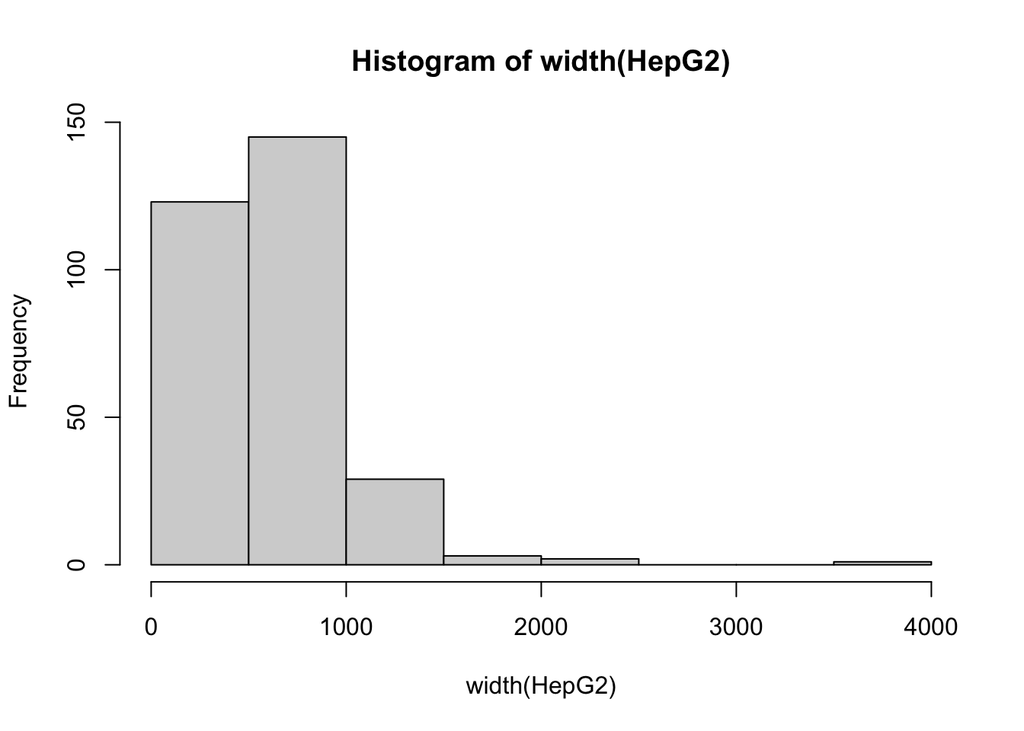

```r
hist(width(HepG2))
```

```r
median_width <- median(width(HepG2))
paste("Median width of all chromosomes: ", median_width)
```

```
## [1] "Median width of all chromosomes:  560"
```

## Bioconductor Infrastructure for genomics, microarray and NGS

- IRanges package - representing ranges of integers. Base pair arrangements we want to manipulate in genomics
- Vignette about classes and functions in IRanges package
- Simple functions have good performance
- Summary of most important functions
- IRanges - start, end, width (i.e., 5, 10, 6bP long)
- Start, end, and width functions
- Can specify > 1 range at a time to make IRanges objects of length n
- Intra-range methods:
- **Shift** - Intra range methods for IRanges - doesn’t depend on other ranges contained in IRanges object. I.e., shift IRange to the left by 2.
- **Narrow** - relative to start, start at nth base pair
- **Flank** - get flanking sequence 3 base pairs from start or end (start = False). Also bi-directional (both=True)
- Inter-range methods:
- **range** - will give beginning of the IRanges to the end, including gaps in between
- **reduce** - gives us base pairs covered by the original ranges (do not get gaps). Can ask for gaps.
- **disjoint** - set of ranges which has the same coverage as original IRanges object but non-overlapping. Contain union of all endpoints of the original range.

### Assessment: IRanges

```r
library(IRanges)
ir <- IRanges(101, 200)
paste("*2 zooms in, giving range with half the width. New starting point: ", start(ir*2))
```

```
## [1] "*2 zooms in, giving range with half the width. New starting point:  126"
```

```r
n_ir <- narrow(ir, start=20)
paste("narrow function with start of 20. New starting point: ", start(n_ir))
```

```
## [1] "narrow function with start of 20. New starting point:  120"
```

```r
paste("+25 operation gives width of resulting range: ", width(ir+25))
```

```
## [1] "+25 operation gives width of resulting range:  150"
```

```r
m_ir <- IRanges(start=c(1, 11, 21),end=c(3, 15, 27))
paste("sum of widths of multiple IRanges objects:", sum(width(m_ir)))
```

```
## [1] "sum of widths of multiple IRanges objects: 15"
```

```r
x <- IRanges(start=c(101,106,201,211,221,301,306,311,351,361,401,411,501), end=c(150,160,210,270,225,310,310,330,390,380,415,470,510))
library(ph525x)
```

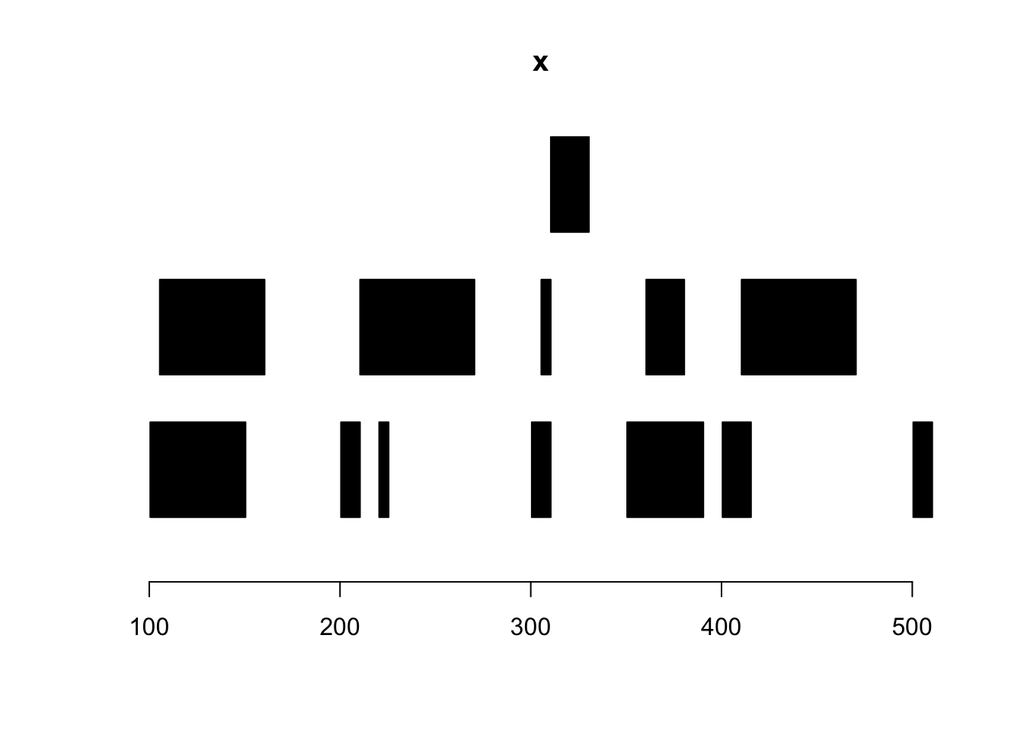

```r
plotRanges(x)
```

```r
paste("Total width not covered by ranges in x:", sum(width(gaps(x))))
```

```
## [1] "Total width not covered by ranges in x: 130"
```

```r
paste("Number of disjoint ranges within ranges in x:", length(disjoin(x)))
```

```
## [1] "Number of disjoint ranges within ranges in x: 17"
```

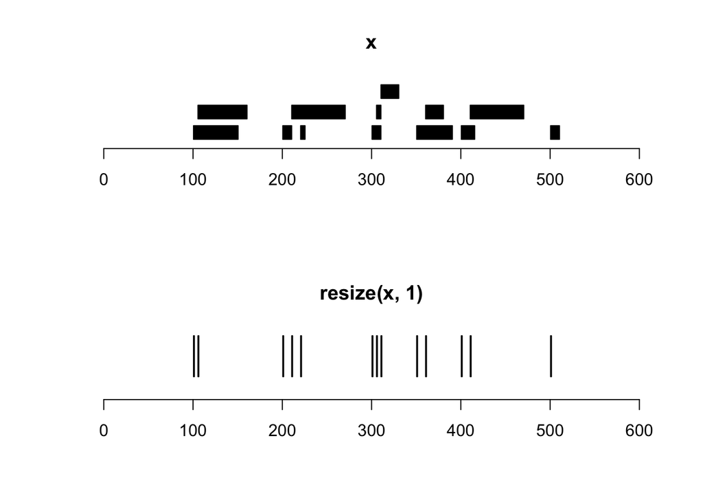

```r
par(mfrow=c(2, 1))
plotRanges(x, xlim=c(0, 600))
plotRanges(resize(x, 1), xlim=c(0, 600))
```

## Genomic ranges: GRanges

- Extension of IRanges
- Contain a sequence name - IRange of chromosome Z.
- Can contain chromosome information and sequence length
- Sequence names as Rle
- IRanges and strange as Rle also
- Can shift similar to IRanges - will go off end of chromosome if exceeds length
- Wrap in trim function to make sure that the end at chromosome end does not exceed
- Metadata accessed with *mcols*
- Can add cols by *mcols$*
- Additional package called *GRangesList* - groups GRanges together by wrapping in function call
- Example of *GRangesList* - grouping exons by gene or by transcript
- Application of package - find overlaps between GRanges objects
- *findOverlaps* function - query and subject (see in help() function)
- output of *findOverlaps* is a hits object with length representing # overlaps
- Same way to get the overlaps is *%over%* function - which returns logical vector
- *Rle* object defined by IRanges but similar object in base R = Run length encoding
- If vector repeats certain values, can save memory by number and number of times repeated
- *str* function gives us the compact representation
- Peering into *Rle* object - can use *Views* object to see *IRanges* from start to end. Only a virtual class - saves *Rle* and number of views / windows into it
- Can also use for *Fasta* files or other objects